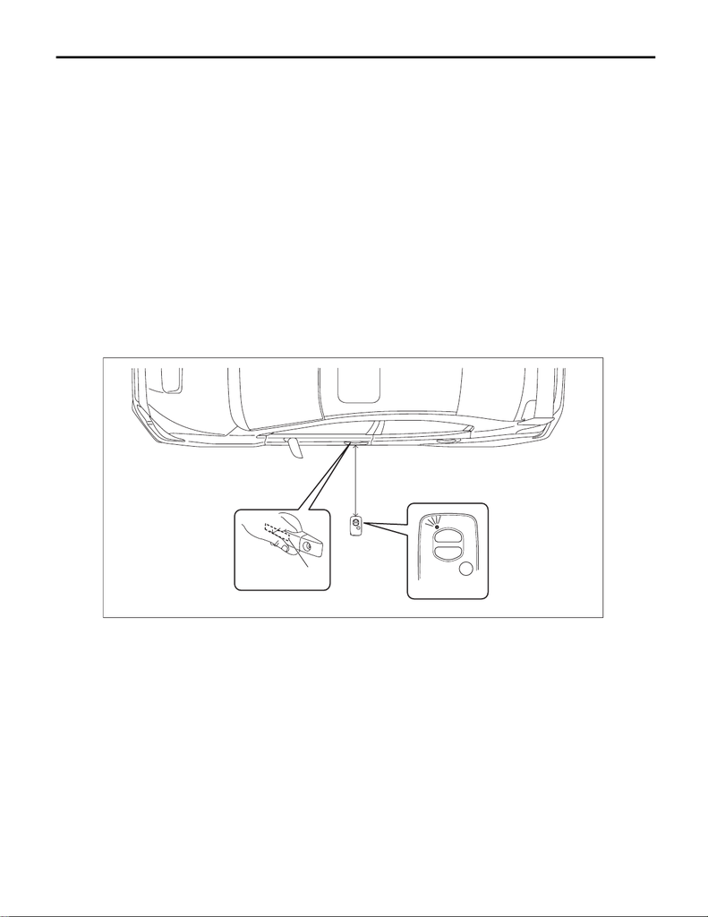

KPS(diag)-5

General Description

KEYLESS ACCESS WITH PUSH BUTTON START SYSTEM (DIAGNOSTICS)

3. General Description

A: CAUTION

1. SRS AIRBAG SYSTEM

The airbag system wiring harness is routed near the keyless access with push button start system.

CAUTION:

• Do not use electrical test equipment on any wiring harnesses and connectors in the airbag system.

• Be careful not to damage the wiring harness of the airbag system when servicing the keyless ac-

cess with push button start system.

2. KEYLESS ACCESS WITH PUSH BUTTON START SYSTEM

NOTE:

• Using the function setting (ECM customizing), check that the keyless access system is not OFF. <Ref. to

SL-119, OPERATION, Function Setting (Customize).>

• The dark current is approx. 400 mA if there is communication between the vehicle and access key.

• The dark current is approx. 40 mA if there is no communication between the vehicle and access key.*

* No communication with the vehicle means that the keyless access function has been cancelled or that the

access key has not been near the vehicle for 15 minutes or more after door locking.

1) Keyless access door unlock function check

(1) When carrying the access key with all doors locked by keyless lock operation, check that when the

touch sensor (unlock) built in to the back side surface of door outer handle of front door is touched, the

driver’s door will unlock (when touched on the driver’s side) or all doors will unlock (when touched on the

passenger’s side) and the answer-back function operates (hazard light blinks twice, access buzzer

sounds twice).

(2) In the keyless access door unlock detection area, hold the access key at the same height as the outer

handle (approx. 80 cm from the ground) and in the direction shown in the figure, and check that the ve-

hicle becomes unlock mode [access key LED (red) blinks] at 40 to 80 cm from the vehicle.

NOTE:

Check the access key battery if the LED (red) does not illuminates when the access key button is pressed.

<Ref. to SL-86, INSPECTION, Access Key.>

(1) Touch sensor (unlock) (2) 40 — 80 cm

SL-02816

(2)

(1)

15WRX_STI_US_EN.book 5 ページ ２０１５年２月１３日 金曜日 午前１１時２０分

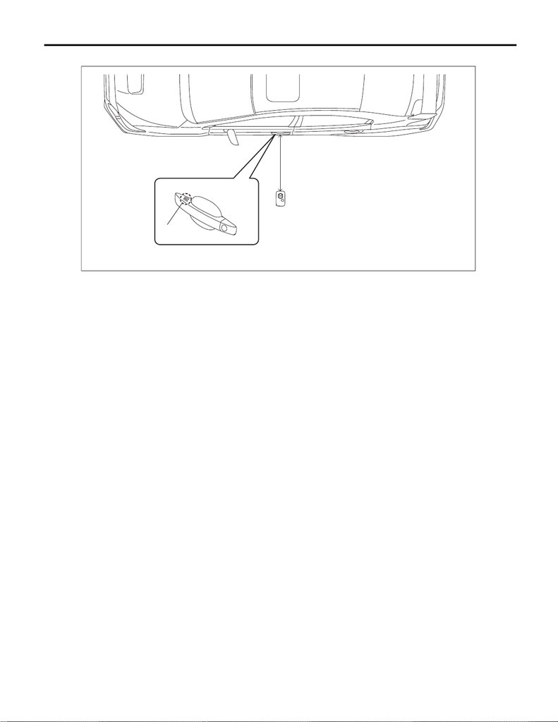

KPS(diag)-6

General Description

KEYLESS ACCESS WITH PUSH BUTTON START SYSTEM (DIAGNOSTICS)

2) Check keyless access door lock function

(1) When carrying the access key outside of the vehicle with all doors closed and unlocked, check that

when the touch sensor (lock) on the surface of door outer handle of front door is touched, all doors will

lock and the answer-back function operates (hazard light blinks once, access buzzer sounds once).

CAUTION:

If the access key is within the vehicle but not within the detection area (in the instrument panel, on

the rear tray, in the glove box, on the floor, or in the door trim pocket), then lockout protection will not

function when the doors are locked and the access key will be locked into the vehicle.

(2) To check the keyless access door lock operation range, hold the access key at a height of 10 cm un-

der the bottom edge of the door glass (approx. 80 cm from the ground) in the direction shown in the figure,

and check that all doors lock and the answer-back function operates (hazard light blinks once, access

buzzer sounds once) when you touch the touch sensor (lock) at a distance of approx. 30 cm from the ve-

hicle.

(3) Check the passenger’s side door in the same manner.

NOTE:

• When the door cannot lock if the touch sensor (lock) is touched, touch the touch sensor (lock) with palm.

• Since communication is not possible within close range (20 cm or less) of the door outer handle, the ac-

cess key may not operate if you touch the touch sensor (lock) with the same hand you are holding the access

key.

• If the lockout prevention buzzer sounds, it is possible that the interior transmitter has radio wave leakage.

(1) Touch sensor (lock) (2) Approx. 30 cm

SL-02817

(2)

(1)

15WRX_STI_US_EN.book 6 ページ ２０１５年２月１３日 金曜日 午前１１時２０分

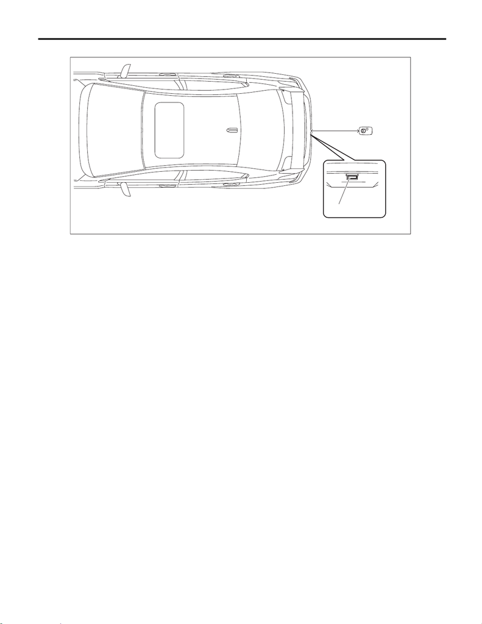

KPS(diag)-7

General Description

KEYLESS ACCESS WITH PUSH BUTTON START SYSTEM (DIAGNOSTICS)

3) Check of the keyless access trunk open function

(1) With the trunk closed, check that the trunk opens and the answer-back function operates (hazard light

blinks twice, access buzzer sounds twice) when you press the trunk opener button while carrying the ac-

cess key.

(2) To check the keyless access trunk open operation range, hold the access key behind and in the cen-

ter of the vehicle at the same height as the trunk opener button (90 cm from the ground) in the direction

shown in the figure, and check that the trunk opens and the answer-back function operates (hazard light

blinks twice, access buzzer sounds twice) when the trunk opener button is pressed at a distance of 40 to

80 cm from the vehicle.

4) Check of the keyless access ignition switching function

(1) With the ignition OFF, enter the vehicle while carrying the access key. Depress the brake pedal with

the shift lever in the “P” range (except for MT model) or depress the clutch pedal (MT model), and check

that the push button ignition switch indicator is illuminated in green, and check that the engine starts when

you press the push button ignition switch.

(2) While carrying the access key, check that when you press the push button ignition switch without de-

pressing the brake pedal (except for MT model) or clutch pedal (MT model), the following occurs: ‘Ignition

OFF’ → ‘ACC ON’ → ‘Ignition ON’ → ‘Ignition OFF’. However on the model except for MT, if the shift lever

is any range except for the “P” range and the push button ignition switch is pressed from ignition ON, then

it will change to ACC ON without changing to ignition OFF.

(3) After the vehicle has stopped, press the push button ignition switch and ignition is turned OFF (engine

stopped · all power supplies OFF). However on the model except for MT, if the shift lever is in any range

except for the “P” range and the push button ignition switch is pressed with the vehicle stopped, then the

power supplies changes to ACC ON without changing to ignition OFF. Check that the steering lock op-

erates if the door is opened in the ignition OFF state. (However, except for MT model, the shift must be

in the “P” range.)

(1) Trunk opener button (2) 40 — 80 cm

SL-02818

(2)

(1)

15WRX_STI_US_EN.book 7 ページ ２０１５年２月１３日 金曜日 午前１１時２０分

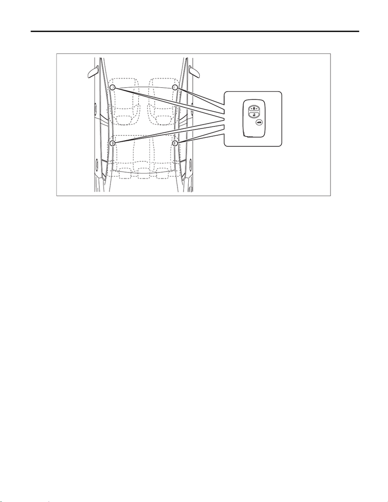

KPS(diag)-8

General Description

KEYLESS ACCESS WITH PUSH BUTTON START SYSTEM (DIAGNOSTICS)

(4) To check the range of the keyless access ignition operation, check that the engine can start when you

set the access key at the check position on the seat in the direction indicated in the figure.

CAUTION:

The access key may not be correctly detected even though it is within the detection area within the

passenger room, if it is on the instrument panel, on the rear tray, in the glove box, on the floor, or in

the door trim pocket.

NOTE:

SL-01483

15WRX_STI_US_EN.book 8 ページ ２０１５年２月１３日 金曜日 午前１１時２０分

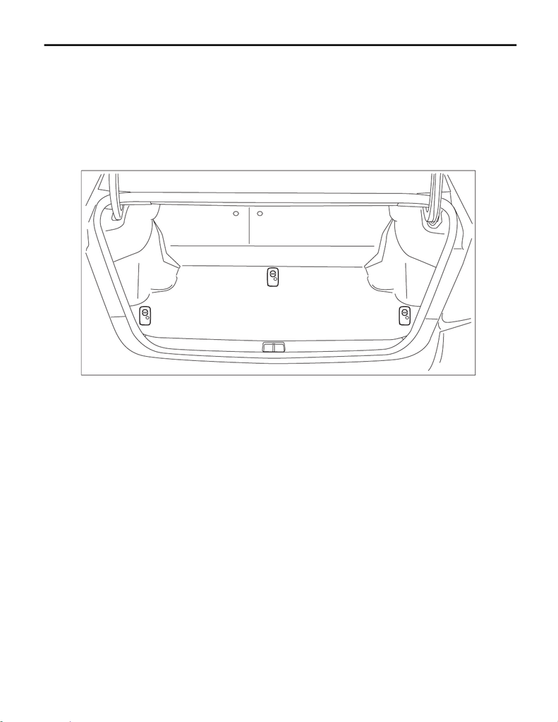

KPS(diag)-9

General Description

KEYLESS ACCESS WITH PUSH BUTTON START SYSTEM (DIAGNOSTICS)

5) Lockout protection function check with the access key in the trunk

CAUTION:

Open one of the windows before performing this check in order to prevent the key from being locked

inside the vehicle.

(1) With all doors closed and locked, and with the access key in the trunk room and the trunk closed,

check that the access buzzer sounds (approx. 2 seconds). Also check that the trunk opens when you

press the trunk opener button.

(2) To check the detection range of the lockout protection function with the access key in the trunk, posi-

tion the access key in the direction shown in the figure, and check that the lockout protection function op-

erates normally when you check the lockout protection function for the access key locked in the trunk.

CAUTION:

The lockout protection function will not operate if the access key is any of the locations described

below.

• Near the spare tire or on the edge of the trunk room.

• Inside a bag made of metallic material or near metal objects.

NOTE:

Check the trunk in two locations or more.

6) Lockout protection function check (in the passenger room)

CAUTION:

Open one of the windows before performing this check in order to prevent the key from being locked

inside the vehicle.

(1) Position the access key on the driver’s or passenger’s seat.

(2) Close all doors. (with all doors unlocked)

(3) Check that the doors do not lock and the lockout protection buzzer (exterior) sounds for 2 seconds

when you touch the touch sensor (lock) of either the driver’s or passenger’s door.

SL-01484

(A)

(B) (C)

15WRX_STI_US_EN.book 9 ページ ２０１５年２月１３日 金曜日 午前１１時２０分

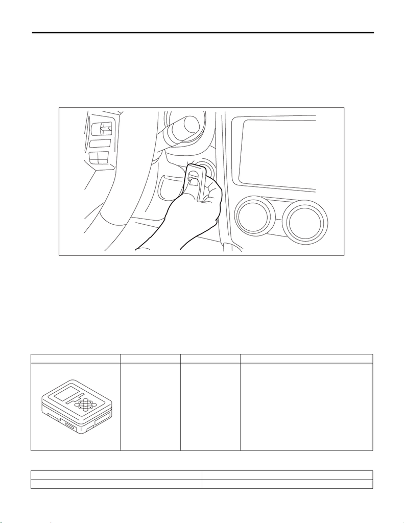

KPS(diag)-10

General Description

KEYLESS ACCESS WITH PUSH BUTTON START SYSTEM (DIAGNOSTICS)

7) Check of the keyless access cancel function

(1) After setting the keyless access cancel function, check that all keyless access and start system (key-

less access) functions are inoperable. (For cancel setting, refer to <Ref. to SL-119, OPERATION, Func-

tion Setting (Customize).>)

NOTE:

When keyless access is cancelled, door lock and unlock can be operated by access key button operation and

the starter system can be operated by passing the access key over the push button ignition switch with the

access key button toward you.

8) Access key diagnostic mode

(1) Connect the Subaru Select Monitor, and select «Work Support» of {Keyless access system}. <Ref. to

KPS(diag)-38, Keyless Access System Check.>

(2) From {Work Support}, select «Function Check Sequence».

(3) From {Function Check Sequence}, select «Keyless access system check».

(4) Select the transmitter to check from the items.

(5) Check that the door lock buzzer sounds (short blips, a continuous beeping sound for the center room

antenna) when the access key is near the selected transmitter or antenna.

B: PREPARATION TOOL

1. SPECIAL TOOL

2. GENERAL TOOL

ILLUSTRATION TOOL NUMBER DESCRIPTION REMARKS

1B022XU0 SUBARU SELECT

MONITOR III KIT

Used for troubleshooting the electrical system.

TOOL NAME REMARKS

Circuit tester Used for measuring resistance, voltage and current.

SL-02251

ST1B022XU0

15WRX_STI_US_EN.book 10 ページ ２０１５年２月１３日 金曜日 午前１１時２０分